# RRBS and Chromatin Modifications

Anna L Tyler

November 03, 2021

The purpose of this workflow is combine data about DNA methylation and chromatin modifications. Here we look at whether the effect of DNA methylation on expression is affected by chromatin state.

```r
all.code.dir <- list.files(here("code"), full.names = TRUE)
for(i in 1:length(all.code.dir)){
    all.fun <- list.files(all.code.dir[i], full.names = TRUE)
    for(j in 1:length(all.fun)){source(all.fun[j])}
}
```

```r
#DNA methylation data aligned across strains
rrbs.strain.mat.file <- here("Results", "RRBS", "Aligned.Methyl.Mats.RDS")
rrbs.mats <- readRDS(rrbs.strain.mat.file)
norm.rrbs <- readRDS(here("Results", "RRBS", "RRBS.Normalized.Position.RDS"))
norm.chrom <- readRDS(file.path(results.dir, "Centered_Chromatin_Mats.RDS"))
strain.expr <- readRDS(here("Data", "RNASeq", "Strain_Mean_C_Expression.RData"))
transcript.info <- readRDS(here("Data", "RNASeq", "RNASeq_gene_info.RData"))
```

```r
scaled.expr <- lapply(strain.expr, scale)
#scaled.expr <- lapply(strain.expr, function(x) x - x[2]) #center on B6

col.table <- as.matrix(read.table(here("Data", "support_files", "strain.color.table.txt"),
sep = "\t", comment.char = "%", stringsAsFactors = FALSE))
```

```r
#match up the genes in the chromatin, expression, and methylation data for ease of use later
rrbs.gene.id <- transcript.info[match(names(rrbs.mats), transcript.info[,"external_gene_name"]),"ensembl_gene_id"]
common.id <- Reduce("intersect", list(rrbs.gene.id, names(norm.chrom), names(strain.expr)))
common.chrom.locale <- match(common.id, names(norm.chrom))
common.rrbs.locale <- match(common.id, rrbs.gene.id)
common.expr.locale <- match(common.id, names(strain.expr))

matched.chrom <- norm.chrom[common.chrom.locale]
matched.rrbs <- rrbs.mats[common.rrbs.locale]
matched.norm.rrbs <- norm.rrbs[common.rrbs.locale]
names(matched.rrbs) <- names(matched.norm.rrbs) <- common.id
matched.expr <- strain.expr[common.expr.locale]

gene.names <- transcript.info[match(common.id, transcript.info[,"ensembl_gene_id"]),"external_gene_name"]
```

## Differential methylation by state

We looked at whether CpG sites were differentially methylated based on the chromatin state surrounding them.

To do this, we first created a set of matrices for each measurement with standardized coordinates. This involves binning both the chromatin and the DNA methylation signals. We lose a little resolution here, but I think the patterns are still clear and reliable.

```r
std.coord <- seq(-0.5, 1.5, 0.05) #relative genomic coordinates for binning chromatin and methylation
coord.mids <- sapply(1:(length(std.coord)-1), function(x) mean(c(std.coord[x], std.coord[(x+1)])))

align_chrom_rrbs <- function(chrom.mat, rrbs.mat, bins){

    bin.mids <- sapply(1:(length(bins)-1), function(x) mean(c(bins[x], bins[(x+1)])))

    chrom.coord <- as.numeric(colnames(chrom.mat))
    rrbs.coord <- as.numeric(colnames(rrbs.mat))

    #bin both sets of coordinates into the standardized coordinates
    chrom.coord.idx <- lapply(1:(length(bins)-1),
        function(x) intersect(which(chrom.coord >= bins[x]), which(chrom.coord < bins[(x+1)])))
    rrbs.coord.idx <- lapply(1:(length(bins)-1),
        function(x) intersect(which(rrbs.coord >= bins[x]), which(rrbs.coord < bins[(x+1)])))

    num.chrom.bin <- sapply(chrom.coord.idx, length)
    num.rrbs.bin <- sapply(rrbs.coord.idx, length)

    #has.data <- sort(union(which(num.chrom.bin > 0), which(num.rrbs.bin > 0)))

    binned.chrom <- lapply(chrom.coord.idx, function(x) if(length(x) > 0){chrom.mat[,x,drop=FALSE]}else{NA})
    binned.rrbs <- lapply(rrbs.coord.idx, function(x) if(length(x) > 0){rrbs.mat[,x,drop=FALSE]})

    #for each state, make a presence/absence matrix identifying whether that
    #state is present in that bin for each strain
    state.bin.mats <- vector(mode = "list", length = num.states)
    for(st in 1:num.states){
        state.mat <- matrix(NA, nrow = nrow(chrom.mat), ncol = length(binned.chrom))
        colnames(state.mat) <- bin.mids
        rownames(state.mat) <- rownames(chrom.mat)
        state.present <- lapply(binned.chrom, function(x) if(length(x) > 1){apply(x, 1, function(y) length(which(y == st)) > 0)})
        for(b in 1:length(state.present)){
            if(length(state.present[[b]]) > 1){
                state.mat[,b] <- as.numeric(state.present[[b]])
            }
        }
        state.bin.mats[[st]] <- state.mat
    }

    #create a similar matrix for the DNA methylation with the average
    #methylation across the bin.
    rrbs.bin.mat <- sapply(binned.rrbs, function(x) if(length(x) > 1){rowMeans(x, na.rm = TRUE)}else{rep(NA, nrow(rrbs.mat))})
    colnames(rrbs.bin.mat) <- bin.mids
    rownames(rrbs.bin.mat) <- rownames(rrbs.mat)
    result <- list("chromatin_mats" = state.bin.mats, "rrbs_mat" = rrbs.bin.mat)
    return(result)
}

aligned.epi.chrom.file <- here("Results", "RRBS", "Aligned.Chromatin.and.RRBS.RDS")
if(!file.exists(aligned.epi.chrom.file)){
    aligned_epi <- lapply_pb(1:length(matched.chrom),
        function(x) if(length(matched.chrom[[x]]) > 1){align_chrom_rrbs(t(matched.chrom[[x]]), matched.norm.rrbs[[x]], std.coord)}else{NA})
    names(aligned_epi) <- names(matched.chrom)
    saveRDS(aligned_epi, aligned.epi.chrom.file)
}else{
    aligned_epi <- readRDS(aligned.epi.chrom.file)
}
```

For each chromatin state, we looked at the percent methylation of CpG sites in the region of the state. The following plots show the median percent methylation of CpG sites in each chromatin state as they appear along the gene body.

There do appear to be differential levels of methylation in the different states.

All states have roughly the same pattern of being hypomethylated at the TSS, and hypermethylated in the gene body. However the degree to which that is true varies.

States 3 and 7 are relatively hypomethylated across the whole gene relative to the other states.

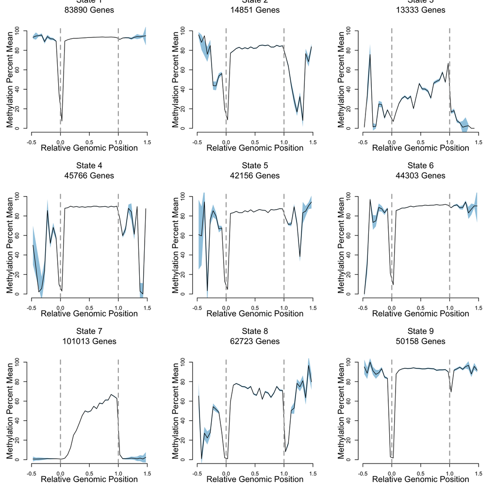

```r
get_methyl_by_state <- function(bin_state_mat, rrbs_mat){
    state_rrbs <- matrix(NA, nrow = nrow(rrbs_mat), ncol = ncol(rrbs_mat))
    rownames(state_rrbs) <- rownames(rrbs_mat)
    colnames(state_rrbs) <- colnames(rrbs_mat)
    state.locale <- which(bin_state_mat > 0)
    state_rrbs[state.locale] <- rrbs_mat[state.locale]
    return(state_rrbs)
}

full_rrbs <- sapply(1:length(aligned_epi), function(x) if(length(aligned_epi[[x]][[1]]) > 1){aligned_epi[[x]][[2]]}else{NA})
has.methyl <- which(sapply(full_rrbs, function(x) !all(is.na(x))))

if(is.interactive){quartz(width = 10, height = 7)}
par(mfrow = c(3,3))
for(state in 1:num.states){
    state_methyl <- sapply(1:length(aligned_epi), function(x) if(length(aligned_epi[[x]][[1]]) > 1){get_methyl_by_state(aligned_epi[[x]][[1]][[state]], aligned_epi[[x]][[2]])}else{NA})
    has.methyl <- which(sapply(state_methyl, function(x) !all(is.na(x))))

    all_strain_list <- lapply(1:9, function(strain) t(sapply(state_methyl[has.methyl], function(x) x[strain,])))
    all_strain_mat <- Reduce("rbind", all_strain_list)
    row.has.val <- which(apply(all_strain_mat, 1, function(x) !all(is.na(x))))

    plot.centered.mat(all_strain_mat[row.has.val,], ylim = c(0,100), plot.fun = "median",
        plot.label = paste("State", state), min.representation = 90,
        min.upstream = -0.5, max.downstream = 1.5)
    abline(v = c(0,1), lty = 2, lwd = 2, col = "darkgray")
}
```

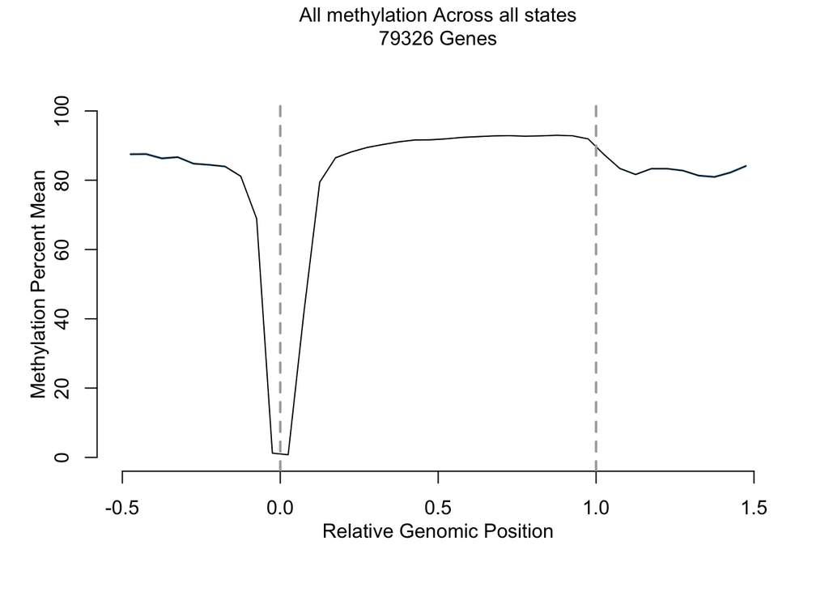

```r
#show percent methylation regardless of state
full_strain_list <- lapply(1:9, function(strain) t(sapply(full_rrbs[has.methyl], function(x) x[strain,])))
full_strain_mat <- Reduce("rbind", full_strain_list)
row.has.val <- which(apply(full_strain_mat, 1, function(x) !all(is.na(x))))
if(is.interactive){quartz(width = 10, height = 7)}
par(mfrow = c(1,1))
plot.centered.mat(full_strain_mat[row.has.val,], ylim = c(0,100), plot.fun = "median",
    plot.label = "All methylation Across all states", min.representation = 90,
    min.upstream = -0.5, max.downstream = 1.5)
abline(v = c(0,1), lty = 2, lwd = 2, col = "darkgray")
```

## Chromatin state, methylation, and expression

We next investigated whether the chromatin state housing the methylated DNA had any effect on the methylation’s effect on expression.

For example, methylating DNA at the TSS in state 7 may have a negative effect on expression, whereas methylating DNA at the TSS in state 3 may have no effect.

State 3 is very interesting in that DNA methylation present in this state tends to have a slight positive correlation with gene expression.

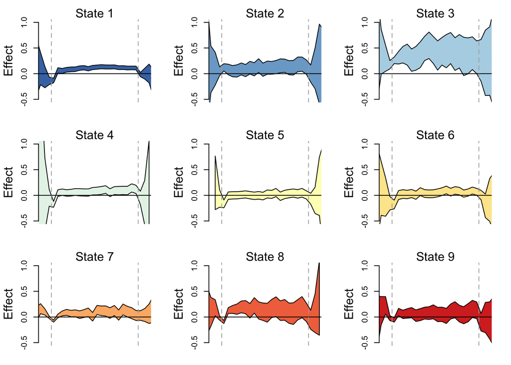

```r
strains <- colnames(matched.chrom[[1]])
expr.order <- match.order(rownames(matched.norm.rrbs[[1]]), names(strain.expr[[1]]), col.table)
methyl_expr_effect <- vector(mode = "list", length = num.states)
names(methyl_expr_effect) <- 1:num.states
for(state in 1:num.states){
    state_methyl <- sapply(1:length(aligned_epi), function(x) if(length(aligned_epi[[x]][[1]]) > 1){get_methyl_by_state(aligned_epi[[x]][[1]][[state]], aligned_epi[[x]][[2]])}else{NA})
    has.methyl <- which(sapply(state_methyl, function(x) !all(is.na(x))))
    strain_cor_list <- vector(mode = "list", length = length(strains))
    names(strain_cor_list) <- strains

    all.strain.methyl <- vector(mode = "list", length = length(strains))
    all.strain.expr <- vector(mode = "list", length = length(strains))

    for(strain in 1:length(strains)){
        methyl_by_strain <- t(sapply(state_methyl[has.methyl], function(x) x[strain,]))
        rownames(methyl_by_strain) <- names(aligned_epi)[has.methyl]
        all.strain.methyl[[strain]] <- methyl_by_strain
        expr.locale <- match(rownames(methyl_by_strain), names(strain.expr))
        comp.expr <- sapply(strain.expr[expr.locale], function(x) x[expr.order[strain]])
        all.strain.expr[[strain]] <- rankZ(comp.expr)
    }

    strain_methyl_effect <- lapply(1:length(all.strain.methyl),
        function(y) sapply(1:ncol(all.strain.methyl[[y]]),
        function(x) plot.with.model(rankZ(all.strain.methyl[[y]][,x]), all.strain.expr[[y]],
        confidence = 0.95, plot.results = FALSE)))

    strain.effect.mat <- Reduce("+", strain_methyl_effect)/length(strain_methyl_effect)
    colnames(strain.effect.mat) <- colnames(all.strain.methyl[[1]])
    rownames(strain.effect.mat) <- c("r", "p.value", "slope.fit", "slope.lwr", "slope.upr")

    methyl_expr_effect[[state]] <- strain.effect.mat
}

coords <- as.numeric(colnames(methyl_expr_effect[[1]]))
state.col <- colors.from.values(1:num.states, use.pheatmap.colors = TRUE,
    global.color.scale = TRUE, global.min = 1, global.max = num.states)

if(is.interactive){quartz(width = 9, height = 9)}
par(mfrow = c(3,3), mar = c(2,4,2,2))
for(state in 1:num.states){
    plot.new()
    plot.window(xlim = c(-0.1, 1.1), ylim = c(-0.5, 1))
    points(coords, methyl_expr_effect[[state]]["slope.fit",], col = state.col[state], type = "l")
    plot.poly.xy(coords, methyl_expr_effect[[state]]["slope.lwr",],
    coords, methyl_expr_effect[[state]]["slope.upr",], col = state.col[state])
    abline(h = 0)
    axis(2)
    mtext(side = 2, "Effect", line = 2.5)
    mtext(side = 3, paste("State", state), line = 0)
    abline(v = c(0,1), lty = 2, col = "darkgray")
}
```

## DNA methylation effects across strains

We also looked for any effect of DNA methylation across strains. This is the same code above, but draws on the scaled expression instead of the TPM data.

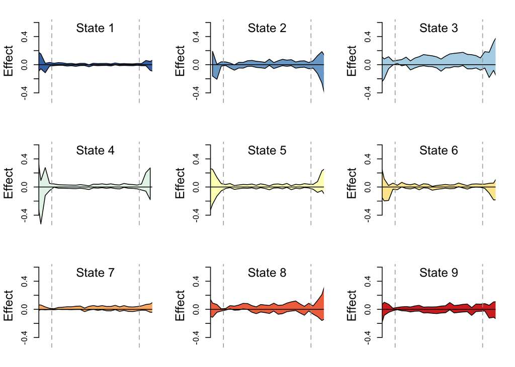

```r
strains <- colnames(matched.chrom[[1]])
expr.order <- match.order(rownames(matched.norm.rrbs[[1]]), names(strain.expr[[1]]), col.table)
min.n.gene = 50
methyl_expr_cor <- vector(mode = "list", length = num.states)
names(methyl_expr_cor) <- 1:num.states
for(state in 1:num.states){
    state_methyl <- sapply(1:length(aligned_epi), function(x) if(length(aligned_epi[[x]][[1]]) > 1){get_methyl_by_state(aligned_epi[[x]][[1]][[state]], aligned_epi[[x]][[2]])}else{NA})
    has.methyl <- which(sapply(state_methyl, function(x) !all(is.na(x))))
    strain_cor_list <- vector(mode = "list", length = length(strains))
    names(strain_cor_list) <- strains

    all.strain.methyl <- vector(mode = "list", length = length(strains))
    all.strain.expr <- vector(mode = "list", length = length(strains))

    for(strain in 1:length(strains)){
        methyl_by_strain <- t(sapply(state_methyl[has.methyl], function(x) x[strain,]))
        rownames(methyl_by_strain) <- names(aligned_epi)[has.methyl]
        all.strain.methyl[[strain]] <- methyl_by_strain
        expr.locale <- match(rownames(methyl_by_strain), names(strain.expr))
        comp.expr <- sapply(scaled.expr[expr.locale], function(x) x[expr.order[strain]])
        all.strain.expr[[strain]] <- comp.expr
    }

    overall_methyl <- Reduce("rbind", all.strain.methyl)
    overall_expr <- Reduce("c", all.strain.expr)

    conf_mat <- matrix(NA, nrow = 5, ncol = ncol(methyl_by_strain))
    colnames(conf_mat) <- colnames(methyl_by_strain)
    rownames(conf_mat) <- c("r", "p.value", "slope.fit", "slope.lwr", "slope.upr")

    min.samples <- which(apply(overall_methyl, 2, function(x) length(which(is.finite(x)))) >= min.n.gene)
    strain.cor.mat <- apply(overall_methyl[,min.samples], 2,
        function(x) plot.with.model(rankZ(x), rankZ(overall_expr),
        confidence = 0.95, plot.results = FALSE))

    conf_mat[,min.samples] <- strain.cor.mat
    methyl_expr_cor[[state]] <- conf_mat
}


coords <- as.numeric(colnames(methyl_expr_cor[[1]]))
state.col <- colors.from.values(1:num.states, use.pheatmap.colors = TRUE,
    global.color.scale = TRUE, global.min = 1, global.max = num.states)

if(is.interactive){quartz(width = 9, height = 9)}
par(mfrow = c(3,3), mar = c(2,4,2,2))
for(state in 1:num.states){
    plot.new()
    plot.window(xlim = c(-0.1, 1.1), ylim = c(-0.5, 0.6))
    points(coords, methyl_expr_cor[[state]]["slope.fit",], col = state.col[state], type = "l")
    plot.poly.xy(coords, methyl_expr_cor[[state]]["slope.lwr",],
    coords, methyl_expr_cor[[state]]["slope.upr",], col = state.col[state])
    abline(h = 0)
    axis(2)
    mtext(side = 2, "Effect", line = 2.5)
    mtext(side = 3, paste("State", state), line = -1.5)
    abline(v = c(0,1), lty = 2, col = "darkgray")
}
```

There seems to be some interaction between chromatin state and the effect of DNA methylation, but there is no interaction when looking across strains.

## Examples

The following plots show the correlations between DNA methylation and gene expression where the chromatin state makes a large difference

## Strong Correlation Examples

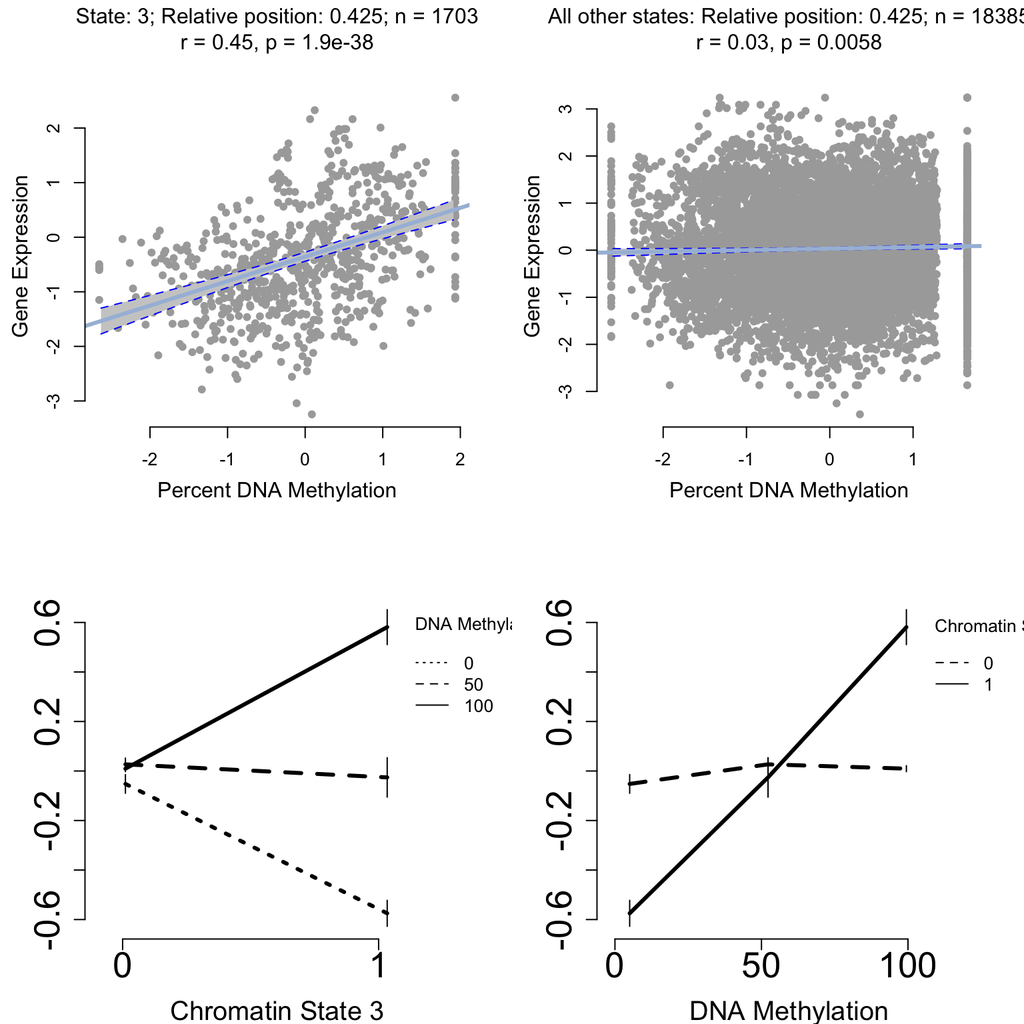

```r
plot.example.cor <- function(state, position, confidence = 0.95){
    pos <- which(coords == position)
    state_chrom <- lapply(aligned_epi, function(x) if(length(x) > 1){x[[1]][[state]]}else{NA})
    full_methyl <- lapply(aligned_epi, function(x) if(length(x) > 1){x[[2]]}else{NA})
    state_methyl <- sapply(1:length(aligned_epi), function(x) if(length(aligned_epi[[x]][[1]]) > 1){get_methyl_by_state(aligned_epi[[x]][[1]][[state]], aligned_epi[[x]][[2]])}else{NA})
    has.methyl <- which(sapply(state_methyl, function(x) !all(is.na(x))))

    all.strain.all.methyl <- all.strain.all.expr <- all.strain.all.chrom <- NULL

    #combine data for all strians
    for(strain in 1:length(strains)){
        chrom_by_strain <- t(sapply(state_chrom[has.methyl], function(x) x[strain,]))
        methyl_by_strain <- t(sapply(full_methyl[has.methyl], function(x) x[strain,]))
        rownames(methyl_by_strain) <- names(aligned_epi)[has.methyl]
        expr.locale <- match(rownames(methyl_by_strain), names(strain.expr))
        comp.expr <- sapply(strain.expr[expr.locale], function(x) x[expr.order[strain]])

        #binned.methyl <- bin.vector(methyl_by_strain[,pos], c(0, 50, 100))
        #quartz();boxplot(comp.expr~chrom_by_strain[,pos]*binned.methyl)
        #quartz();interaction.plot(binned.methyl, chrom_by_strain[,pos], comp.expr, trace.label = paste("Chromatin State", state), xlab = "DNA Methylation Percent",ylab = "Gene Expression")

        all.strain.all.methyl <- rbind(all.strain.all.methyl, methyl_by_strain)
        all.strain.all.chrom <- rbind(all.strain.all.chrom, chrom_by_strain)
        scaled.expr <- rankZ(comp.expr)
        scaled.vector <- scaled.expr
        all.strain.all.expr <- c(all.strain.all.expr, scaled.vector)
    }

    if(is.interactive){quartz(width = 8, height = 8)}
    par(mfrow = c(2,2), mar = c(4, 4, 4, 2))
    #gene.strain <- sapply(strsplit(names(all.strain.all.expr), "[.]"), function(x) x[2])
    #strain.col <- col.table[match(gene.strain, col.table[,4]),3]
    has.state <- which(all.strain.all.chrom[,pos] == 1)
    no.state <- which(all.strain.all.chrom[,pos] == 0)

    plot.with.model(rankZ(all.strain.all.methyl[has.state,pos]),
    rankZ(all.strain.all.expr[has.state]),
    xlab = "Percent DNA Methylation", ylab = "Gene Expression", report = "cor.test",
    main = paste0("State: ", state, "; Relative position: ", coord.mids[pos], "; n = ",
    length(has.state)), confidence = confidence, col = "darkgray")

    plot.with.model(rankZ(all.strain.all.methyl[no.state,pos]),
    rankZ(all.strain.all.expr[no.state]),
    xlab = "Percent DNA Methylation", ylab = "Gene Expression", report = "cor.test",
    main = paste0("All other states: Relative position: ", coord.mids[pos], "; n = ",
    length(no.state)), confidence = confidence, col = "darkgray")

    binned.methyl <- bin.vector(all.strain.all.methyl[,pos], c(0, 50, 100))
    plot_lines(rankZ(all.strain.all.expr), all.strain.all.chrom[,pos], binned.methyl,
    error_bars = "se", marker1_label = paste("Chromatin State", state),
    marker2_label = "DNA Methylation", pheno_name = "")

    plot_lines(phenoV = rankZ(all.strain.all.expr), marker1_vals = binned.methyl,
    marker2_vals = all.strain.all.chrom[,pos],
    error_bars = "se", marker2_label = paste("Chromatin State", state),
    marker1_label = "DNA Methylation", pheno_name = "")

    #plot_lines(all.strain.all.expr, binned.methyl, all.strain.all.chrom[,pos], error_bars = "se",marker1_label = paste("Chromatin State", state), marker2_label = "DNA Methylation",pheno_name = "")

    #boxplot(all.strain.all.expr~binned.methyl*all.strain.all.chrom[,pos])
}


state = 3; pos = coords[19]
plot.example.cor(state = state, position = pos, confidence = 0.99)
```

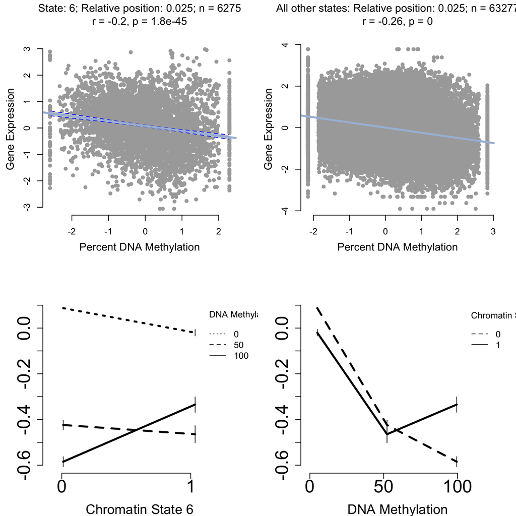

```r
state = 6; pos = 0.025
plot.example.cor(state = state, position = pos, confidence = 0.99)
```